# Homework 8

Ricardo Aguirre

2025-04-14

UT EID: Rea2462 Github link:

## Problem 1: Regression Warm-Up

### Part A

```
## (Intercept)         age
## 147.8129158  -0.6198159
```

```
##       1
## 113.723
```

According to the regression model, the creatinine clearance rate for a 55-year-old is 113.72 ml/minute. This result was calculated using the `lm()` and `coef()` functions to find the Intercept(Beta 0) and slope (Beta 1) which were approximately 147.81 and -0.62. The `predict()` function was used to predict the data for a 55-year-old.

### Part B

According to the regression model created above the effective creatine clearance rate for all ages decreases by a factor of approximately 0.62 ml/minute. This result was calculated the `lm()` and `coef` functions to find both B0(intercept) and B1(slope).

```
## [1] 11.98
```

```
## [1] 1.38
```

### Part C

Using the previously calculated B0 and B1 values I calculated the predicted creatine clearance rate(ml/minute) for both age groups. This was performed by plugging in both beta values into the linear regression equation(creatineclear = B0 - B1 * age). The residuals(actual - predicted) were calculated for both the 40-year-old and 60-year-old to account for make fair comparisons accounting for age and other confounding variables. The 40-year-old had a residual value of + 11.98 while the 60-year-old was +1.38. Seeing as the 40-year-old had a higher residual value we can say that they were healthier than the 60-year-old.

## Problem 2: Modeling Disease Growth

### Italy Growth Rate/Double Time:

```
##            (Intercept) days_since_first_death
##               1.018602               0.183218
```

```
## days_since_first_death
##                      0
```

```
## days_since_first_death
##               0.183218
```

```
## days_since_first_death
##                    3.8
```

```
##                     name     lower     upper level     method  estimate
## 1 days_since_first_death 0.1589456 0.2080458  0.95 percentile 0.2087519
```

```
##      lower    upper
## 1 3.331705 4.360909
```

We fit an exponential model to Italy’s COVID-19 deaths using the formula:

log(deaths) = B0 + B1 *days_since_first_death

From our model the growth rate was 0.183. This means that the log number of deaths increased by 0.183 per day in Italy.

Using bootstrap sampling with replacement, a 95% confidence interval was calculated (0.160, 0.208). This means that we are 95% sure that Italy’s exponential growth rate lies between this interval.

The estimated doubling time was calculated using the equation

double time = log(2)/ growth rate

### Spain Growth Rate/Doubling Time

```
##            (Intercept) days_since_first_death
##              0.4652173              0.2762447
```

```
## days_since_first_death
##                  0.276
```

```
## days_since_first_death
##                    2.5
```

```
##                     name     lower     upper level     method  estimate
## 1 days_since_first_death 0.2355984 0.3177236  0.95 percentile 0.2435293
```

```
##      lower   upper
## 1 2.181604 2.94207
```

We fit an exponential model to Spain’s COVID-19 deaths using the formula:

log(deaths) = B0 + B1 *days_since_first_death

The estimated doubling time was calculated using the equation

double time = log(2)/ growth rate

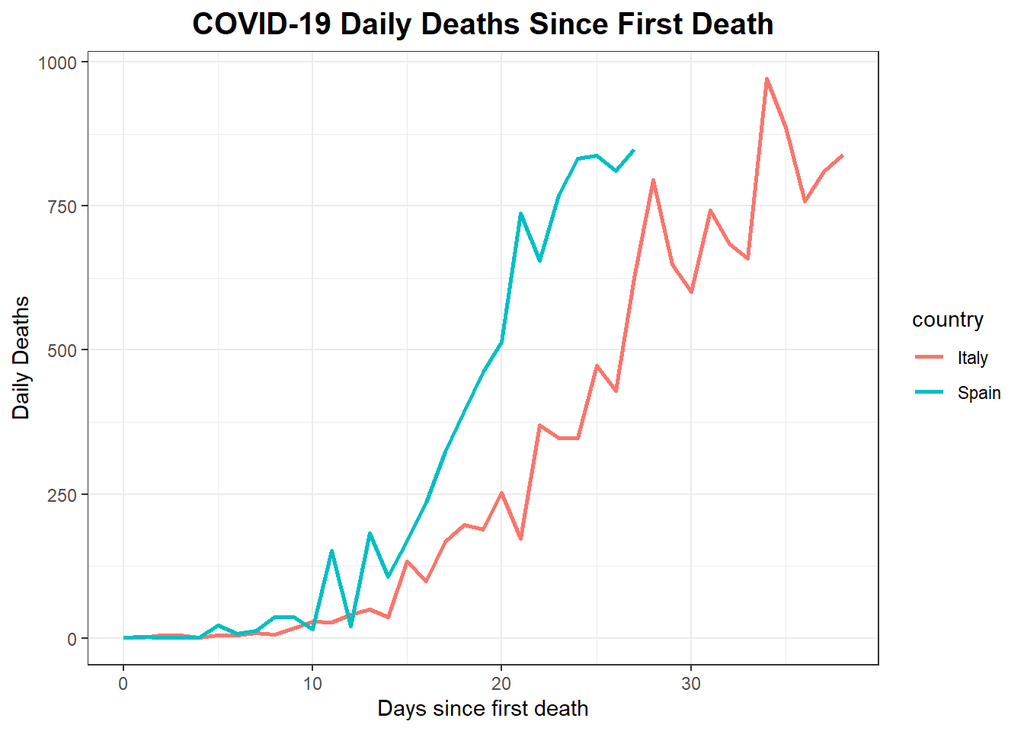

## Problem 3: Price Elasticity of Demand

```
## (Intercept)  log(price)
##    4.720604   -1.618578
```

```
##   Intercept log.price.     sigma r.squared        F numdf dendf .row .index
## 1  4.661934  -1.569743 0.2642521 0.7629248 366.8601     1   114    1      1
## 2  4.723601  -1.638801 0.2380417 0.8439694 616.6259     1   114    1      2
## 3  4.776752  -1.645766 0.2788499 0.7673668 376.0418     1   114    1      3
## 4  4.583178  -1.506613 0.2666911 0.7510568 343.9358     1   114    1      4
## 5  4.724359  -1.598232 0.2299803 0.8240975 534.0862     1   114    1      5
## 6  4.474373  -1.408217 0.2715334 0.6913808 255.3872     1   114    1      6
```

```
##         name       lower       upper level     method    estimate
## 1  Intercept   4.5360711   4.8844118  0.95 percentile   4.7712128
## 2 log.price.  -1.7706463  -1.4553797  0.95 percentile  -1.6623546
## 3      sigma   0.2314014   0.3002170  0.95 percentile   0.2725183
## 4  r.squared   0.6877415   0.8446206  0.95 percentile   0.8097401
## 5          F 251.0820814 619.6879724  0.95 percentile 485.1804128
```